# InteroMap — MAIA Subscale Exploratory Models

Each MAIA-2 subscale as a predictor in the outcome models

# Purpose

Exploratory check of whether trait interoceptive awareness (the eight MAIA-2 subscales) is associated with the drawing outcomes. Each subscale is added as a predictor in a separate model, on top of the pre-registered structure:

$$\text{outcome}_z \sim \text{timepoint}
\times \text{group} + \text{MAIA\_subscale} + (1 \mid
\text{PID})$$

Outcomes are z-scored within study; MAIA subscales are z-scored within study, so the reported coefficient is the expected change in the outcome (in SD units) per 1 SD of the subscale. MAIA-2 is trait-level and constant within a participant, so this is a between-person association.

# Load and prepare

```r
df1 <- read_csv(file.path(base_dir, "interomap_study1_data.csv"), show_col_types = FALSE)
df2 <- read_csv(file.path(base_dir, "interomap_study2_data.csv"), show_col_types = FALSE)

maia_subscales <- c(
  "Noticing"              = "MAIA_Noticing",
  "Not-Distracting"       = "MAIA_NotDistract",
  "Not-Worrying"          = "MAIA_NotWorry",
  "Attention Regulation"  = "MAIA_AttnReg",
  "Emotional Awareness"   = "MAIA_EmoAware",
  "Self-Regulation"       = "MAIA_SelfReg",
  "Body Listening"        = "MAIA_BodyListen",
  "Trusting"              = "MAIA_Trusting"
)

# Z-score outcomes and MAIA subscales within study.
prepare <- function(df) {
  df |>
    mutate(
      # z-scored outcomes
      avg_valence_z             = as.numeric(scale(avg_valence_combined)),
      avg_intensity_z           = as.numeric(scale(avg_intensity_combined)),
      extent_log_z              = as.numeric(scale(log(extent_combined + 1))),
      valence_by_extent_log_z   = as.numeric(scale(log(valence_by_extent_combined + 1))),
      intensity_by_extent_log_z = as.numeric(scale(log(intensity_by_extent_combined + 1))),
      centroid_x_front_z        = as.numeric(scale(centroid_x_front)),
      centroid_y_front_z        = as.numeric(scale(centroid_y_front)),
      sd_x_front_z              = as.numeric(scale(sd_x_front)),
      sd_y_front_z              = as.numeric(scale(sd_y_front)),
      entropy_15_front_z        = as.numeric(scale(entropy_15_front)),
      # z-scored MAIA subscales
      across(all_of(unname(maia_subscales)), ~ as.numeric(scale(.x))),
      timepoint = factor(timepoint, levels = c("pre", "post")),
      group     = factor(group, levels = c("non_gambler", "gambler")),
      PID       = factor(PID)
    )
}

df1 <- prepare(df1)
df2 <- prepare(df2)

study1_outcomes <- c(
  "Valence"                    = "avg_valence_z",
  "Intensity"                  = "avg_intensity_z",
  "Extent (log)"               = "extent_log_z",
  "Valence x Extent (log)"     = "valence_by_extent_log_z",
  "Intensity x Extent (log)"   = "intensity_by_extent_log_z",
  "Centroid x"                 = "centroid_x_front_z",
  "Centroid y"                 = "centroid_y_front_z",
  "SD x"                       = "sd_x_front_z",
  "SD y"                       = "sd_y_front_z",
  "Entropy (15)"               = "entropy_15_front_z"
)

study2_outcomes <- c(
  "Valence"      = "avg_valence_z",
  "Centroid y"   = "centroid_y_front_z",
  "SD x"         = "sd_x_front_z",
  "Entropy (15)" = "entropy_15_front_z"
)
```

# Fit models

```r
# lmer with Satterthwaite df; returns only the MAIA subscale coefficient.
fit_maia <- function(df, outcome_col, sub_col) {
  f <- as.formula(paste(outcome_col, "~ timepoint * group +", sub_col, "+ (1 | PID)"))
  s <- summary(lmer(f, data = df, REML = TRUE))$coefficients
  s[sub_col, , drop = FALSE]
}

run_study <- function(df, outcomes) {
  lapply(names(outcomes), function(onm) {
    dv <- outcomes[[onm]]
    lapply(names(maia_subscales), function(snm) {
      r <- fit_maia(df, dv, maia_subscales[[snm]])
      data.frame(
        outcome  = onm,
        subscale = snm,
        estimate = r[1, "Estimate"],
        se       = r[1, "Std. Error"],
        df       = r[1, "df"],
        t        = r[1, "t value"],
        p        = r[1, "Pr(>|t|)"],
        stringsAsFactors = FALSE
      )
    }) |>
      bind_rows()
  }) |>
    bind_rows()
}

res1 <- run_study(df1, study1_outcomes) |> mutate(study = "Study 1")
res2 <- run_study(df2, study2_outcomes) |> mutate(study = "Study 2")

results <- bind_rows(res1, res2) |>
  mutate(
    subscale = factor(subscale, levels = rev(names(maia_subscales))),
    ci_lo = estimate - 1.96 * se,   # Wald 95% CI for the forest plot
    ci_hi = estimate + 1.96 * se
  )

# APA-formatted table view (subscales in questionnaire order, Noticing first).
maia_apa_table <- function(dat) {
  dat |>
    mutate(
      subscale = factor(subscale, levels = rev(levels(subscale))),
      b        = round(estimate, 2),
      SE       = round(se, 2),
      df       = round(df, 1),
      t        = round(t, 2),
      p        = fmt_p(p),
      `95% CI` = sprintf("[%.2f, %.2f]", ci_lo, ci_hi)
    ) |>
    arrange(outcome, subscale) |>
    select(Outcome = outcome, Subscale = subscale, b, SE, df, t, p, `95% CI`)
}
```

# Results

## Study 1

```r
s1_tab <- maia_apa_table(filter(results, study == "Study 1"))

cat(apa_tab_caption("MAIA Subscale Fixed Effects \u2014 Study 1 (Outcome and Subscale z-Scored)"), "\n")
```

**Table 1**

*MAIA Subscale Fixed Effects — Study 1 (Outcome and Subscale z-Scored)*

```r
apa_table(s1_tab, "maia_study1", tab_dir)
```

| Outcome | Subscale | b | SE | df | t | p | 95% CI |
| --- | --- | --- | --- | --- | --- | --- | --- |
| Centroid x | Noticing | 0.09 | 0.07 | 170.3 | 1.25 | .213 | [-0.05, 0.22] |
| Centroid x | Not-Distracting | 0.01 | 0.07 | 173.3 | 0.21 | .833 | [-0.12, 0.15] |
| Centroid x | Not-Worrying | -0.04 | 0.07 | 178.3 | -0.60 | .549 | [-0.17, 0.09] |
| Centroid x | Attention Regulation | -0.12 | 0.07 | 171.1 | -1.81 | .072 | [-0.26, 0.01] |
| Centroid x | Emotional Awareness | 0.08 | 0.07 | 174.4 | 1.14 | .258 | [-0.06, 0.21] |
| Centroid x | Self-Regulation | -0.04 | 0.07 | 175.0 | -0.58 | .561 | [-0.17, 0.09] |
| Centroid x | Body Listening | 0.06 | 0.07 | 172.6 | 0.89 | .373 | [-0.07, 0.20] |
| Centroid x | Trusting | -0.01 | 0.07 | 176.8 | -0.18 | .856 | [-0.15, 0.12] |
| Centroid y | Noticing | 0.11 | 0.07 | 186.1 | 1.64 | .102 | [-0.02, 0.24] |
| Centroid y | Not-Distracting | 0.03 | 0.07 | 188.1 | 0.42 | .679 | [-0.10, 0.16] |
| Centroid y | Not-Worrying | 0.05 | 0.07 | 193.1 | 0.75 | .457 | [-0.08, 0.18] |
| Centroid y | Attention Regulation | 0.19 | 0.07 | 187.5 | 2.91 | .004 | [0.06, 0.33] |
| Centroid y | Emotional Awareness | -0.03 | 0.07 | 188.9 | -0.45 | .657 | [-0.16, 0.10] |
| Centroid y | Self-Regulation | 0.09 | 0.07 | 189.9 | 1.43 | .156 | [-0.04, 0.22] |
| Centroid y | Body Listening | 0.07 | 0.07 | 187.7 | 1.09 | .276 | [-0.06, 0.21] |
| Centroid y | Trusting | 0.14 | 0.07 | 190.7 | 2.05 | .042 | [0.01, 0.27] |
| Entropy (15) | Noticing | 0.08 | 0.07 | 182.7 | 1.11 | .268 | [-0.06, 0.21] |
| Entropy (15) | Not-Distracting | -0.08 | 0.07 | 185.1 | -1.27 | .205 | [-0.22, 0.05] |
| Entropy (15) | Not-Worrying | -0.10 | 0.07 | 190.8 | -1.55 | .122 | [-0.23, 0.03] |
| Entropy (15) | Attention Regulation | -0.02 | 0.07 | 185.2 | -0.30 | .764 | [-0.15, 0.11] |
| Entropy (15) | Emotional Awareness | 0.13 | 0.07 | 186.7 | 1.96 | .052 | [-0.00, 0.26] |
| Entropy (15) | Self-Regulation | 0.07 | 0.07 | 187.1 | 1.05 | .295 | [-0.06, 0.20] |
| Entropy (15) | Body Listening | 0.04 | 0.07 | 184.8 | 0.60 | .552 | [-0.09, 0.17] |
| Entropy (15) | Trusting | -0.01 | 0.07 | 188.7 | -0.20 | .842 | [-0.14, 0.12] |
| Extent (log) | Noticing | 0.07 | 0.07 | 206.7 | 1.08 | .283 | [-0.06, 0.20] |
| Extent (log) | Not-Distracting | -0.12 | 0.06 | 207.1 | -1.85 | .066 | [-0.25, 0.01] |
| Extent (log) | Not-Worrying | -0.01 | 0.07 | 209.9 | -0.10 | .918 | [-0.13, 0.12] |
| Extent (log) | Attention Regulation | 0.02 | 0.07 | 206.4 | 0.33 | .743 | [-0.11, 0.15] |
| Extent (log) | Emotional Awareness | 0.10 | 0.07 | 206.9 | 1.53 | .127 | [-0.03, 0.23] |
| Extent (log) | Self-Regulation | 0.08 | 0.06 | 209.0 | 1.21 | .228 | [-0.05, 0.21] |
| Extent (log) | Body Listening | 0.00 | 0.07 | 207.5 | 0.07 | .942 | [-0.13, 0.14] |
| Extent (log) | Trusting | -0.04 | 0.07 | 208.4 | -0.69 | .491 | [-0.17, 0.08] |
| Intensity | Noticing | -0.05 | 0.06 | 198.3 | -0.85 | .398 | [-0.17, 0.07] |
| Intensity | Not-Distracting | -0.02 | 0.06 | 198.8 | -0.29 | .769 | [-0.14, 0.10] |
| Intensity | Not-Worrying | -0.08 | 0.06 | 204.8 | -1.34 | .182 | [-0.20, 0.04] |
| Intensity | Attention Regulation | -0.08 | 0.06 | 198.2 | -1.25 | .213 | [-0.20, 0.04] |
| Intensity | Emotional Awareness | 0.09 | 0.06 | 197.4 | 1.55 | .122 | [-0.02, 0.21] |
| Intensity | Self-Regulation | 0.02 | 0.06 | 201.9 | 0.40 | .689 | [-0.09, 0.14] |
| Intensity | Body Listening | 0.04 | 0.06 | 199.1 | 0.63 | .526 | [-0.08, 0.16] |
| Intensity | Trusting | -0.04 | 0.06 | 201.3 | -0.63 | .526 | [-0.16, 0.08] |
| Intensity x Extent (log) | Noticing | 0.02 | 0.07 | 203.6 | 0.27 | .785 | [-0.11, 0.15] |
| Intensity x Extent (log) | Not-Distracting | -0.14 | 0.07 | 203.5 | -2.22 | .027 | [-0.27, -0.02] |
| Intensity x Extent (log) | Not-Worrying | -0.10 | 0.07 | 206.4 | -1.50 | .136 | [-0.23, 0.03] |
| Intensity x Extent (log) | Attention Regulation | -0.05 | 0.07 | 203.4 | -0.68 | .495 | [-0.18, 0.09] |
| Intensity x Extent (log) | Emotional Awareness | 0.11 | 0.07 | 203.5 | 1.69 | .093 | [-0.02, 0.24] |
| Intensity x Extent (log) | Self-Regulation | 0.00 | 0.07 | 205.6 | 0.04 | .965 | [-0.13, 0.13] |
| Intensity x Extent (log) | Body Listening | 0.00 | 0.07 | 204.2 | 0.03 | .976 | [-0.13, 0.14] |
| Intensity x Extent (log) | Trusting | -0.09 | 0.07 | 205.2 | -1.36 | .175 | [-0.22, 0.04] |
| SD x | Noticing | 0.05 | 0.07 | 187.1 | 0.76 | .451 | [-0.08, 0.18] |
| SD x | Not-Distracting | -0.07 | 0.07 | 189.8 | -1.11 | .270 | [-0.20, 0.06] |
| SD x | Not-Worrying | -0.09 | 0.06 | 196.2 | -1.33 | .186 | [-0.21, 0.04] |
| SD x | Attention Regulation | 0.04 | 0.07 | 189.7 | 0.54 | .591 | [-0.10, 0.17] |
| SD x | Emotional Awareness | 0.08 | 0.07 | 191.2 | 1.26 | .208 | [-0.05, 0.21] |
| SD x | Self-Regulation | 0.06 | 0.06 | 192.1 | 0.89 | .376 | [-0.07, 0.18] |
| SD x | Body Listening | 0.05 | 0.07 | 189.1 | 0.73 | .469 | [-0.08, 0.18] |
| SD x | Trusting | 0.06 | 0.07 | 193.5 | 0.95 | .343 | [-0.07, 0.19] |
| SD y | Noticing | 0.05 | 0.07 | 190.6 | 0.81 | .417 | [-0.08, 0.18] |
| SD y | Not-Distracting | -0.07 | 0.06 | 193.5 | -1.04 | .298 | [-0.19, 0.06] |
| SD y | Not-Worrying | -0.06 | 0.06 | 200.1 | -0.95 | .346 | [-0.19, 0.06] |
| SD y | Attention Regulation | 0.05 | 0.07 | 193.3 | 0.82 | .412 | [-0.07, 0.18] |
| SD y | Emotional Awareness | 0.06 | 0.06 | 195.3 | 0.98 | .326 | [-0.06, 0.19] |
| SD y | Self-Regulation | 0.07 | 0.06 | 196.1 | 1.18 | .240 | [-0.05, 0.20] |
| SD y | Body Listening | 0.07 | 0.06 | 192.8 | 1.08 | .283 | [-0.06, 0.20] |
| SD y | Trusting | -0.03 | 0.06 | 197.5 | -0.50 | .618 | [-0.16, 0.09] |
| Valence | Noticing | 0.18 | 0.06 | 205.0 | 3.05 | .003 | [0.06, 0.30] |
| Valence | Not-Distracting | 0.16 | 0.06 | 205.3 | 2.64 | .009 | [0.04, 0.27] |
| Valence | Not-Worrying | 0.20 | 0.06 | 212.2 | 3.47 | < .001 | [0.09, 0.32] |
| Valence | Attention Regulation | 0.24 | 0.06 | 203.9 | 3.99 | < .001 | [0.12, 0.35] |
| Valence | Emotional Awareness | 0.22 | 0.06 | 204.1 | 3.72 | < .001 | [0.10, 0.33] |
| Valence | Self-Regulation | 0.29 | 0.06 | 209.4 | 5.20 | < .001 | [0.18, 0.41] |
| Valence | Body Listening | 0.12 | 0.06 | 206.3 | 1.93 | .054 | [-0.00, 0.24] |
| Valence | Trusting | 0.28 | 0.06 | 208.3 | 4.91 | < .001 | [0.17, 0.39] |
| Valence x Extent (log) | Noticing | 0.06 | 0.07 | 203.1 | 0.92 | .358 | [-0.07, 0.19] |
| Valence x Extent (log) | Not-Distracting | -0.11 | 0.07 | 203.4 | -1.73 | .086 | [-0.24, 0.02] |
| Valence x Extent (log) | Not-Worrying | -0.05 | 0.07 | 206.3 | -0.75 | .453 | [-0.18, 0.08] |
| Valence x Extent (log) | Attention Regulation | 0.02 | 0.07 | 202.9 | 0.27 | .785 | [-0.11, 0.15] |
| Valence x Extent (log) | Emotional Awareness | 0.14 | 0.07 | 203.1 | 2.12 | .035 | [0.01, 0.27] |
| Valence x Extent (log) | Self-Regulation | 0.06 | 0.07 | 205.4 | 0.91 | .364 | [-0.07, 0.19] |
| Valence x Extent (log) | Body Listening | 0.02 | 0.07 | 204.0 | 0.34 | .735 | [-0.11, 0.16] |
| Valence x Extent (log) | Trusting | -0.03 | 0.07 | 204.9 | -0.42 | .678 | [-0.16, 0.10] |

```r
cat("\n*Note.* b = standardised coefficient (outcome SD per 1 SD of subscale); Wald 95% CI; df = Satterthwaite degrees of freedom. Models also include timepoint, group and their interaction (not shown).\n")
```

*Note.* b = standardised coefficient (outcome SD per 1 SD of subscale); Wald 95% CI; df = Satterthwaite degrees of freedom. Models also include timepoint, group and their interaction (not shown).

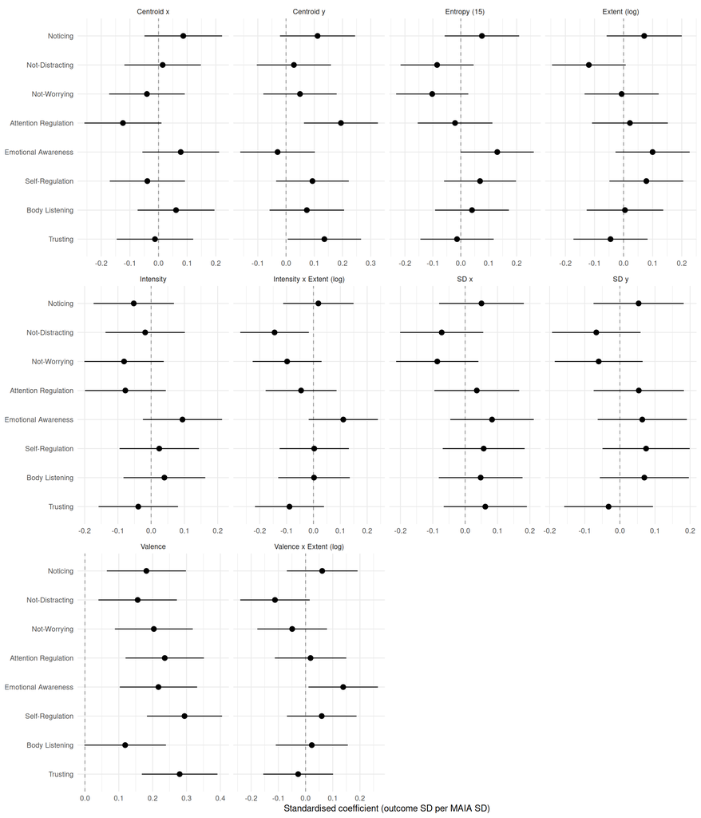

```r
f1 <- results |>
  filter(study == "Study 1") |>
  ggplot(aes(x = estimate, y = subscale, xmin = ci_lo, xmax = ci_hi)) +
  geom_vline(xintercept = 0, linetype = 2, colour = "grey60") +
  geom_pointrange() +
  facet_wrap(~ outcome, scales = "free_x") +
  labs(x = "Standardised coefficient (outcome SD per MAIA SD)", y = NULL) +
  theme_minimal()

apa_fig(f1, "maia_forest_study1", fig_dir, width = 12, height = 14)
f1
```

```r
cat("\n", apa_fig_caption("Standardised association of each MAIA-2 subscale with each outcome \u2014 Study 1"), "\n")
```

```
##
##  **Figure 1**
##
## *Standardised association of each MAIA-2 subscale with each outcome — Study 1*
```

## Study 2

```r
s2_tab <- maia_apa_table(filter(results, study == "Study 2"))

cat(apa_tab_caption("MAIA Subscale Fixed Effects \u2014 Study 2 (Outcome and Subscale z-Scored)"), "\n")
```

**Table 2**

*MAIA Subscale Fixed Effects — Study 2 (Outcome and Subscale z-Scored)*

```r
apa_table(s2_tab, "maia_study2", tab_dir)
```

| Outcome | Subscale | b | SE | df | t | p | 95% CI |
| --- | --- | --- | --- | --- | --- | --- | --- |
| Centroid y | Noticing | -0.07 | 0.05 | 325.4 | -1.53 | .128 | [-0.17, 0.02] |
| Centroid y | Not-Distracting | 0.02 | 0.05 | 333.4 | 0.37 | .711 | [-0.08, 0.11] |
| Centroid y | Not-Worrying | 0.05 | 0.05 | 324.1 | 0.99 | .324 | [-0.05, 0.14] |
| Centroid y | Attention Regulation | -0.02 | 0.05 | 332.9 | -0.37 | .709 | [-0.11, 0.07] |
| Centroid y | Emotional Awareness | -0.04 | 0.05 | 320.4 | -0.73 | .465 | [-0.13, 0.06] |
| Centroid y | Self-Regulation | -0.05 | 0.05 | 326.6 | -0.97 | .335 | [-0.14, 0.05] |
| Centroid y | Body Listening | -0.01 | 0.05 | 328.3 | -0.10 | .917 | [-0.10, 0.09] |
| Centroid y | Trusting | -0.04 | 0.05 | 331.8 | -0.76 | .445 | [-0.13, 0.06] |
| Entropy (15) | Noticing | 0.01 | 0.05 | 334.1 | 0.23 | .818 | [-0.09, 0.11] |
| Entropy (15) | Not-Distracting | -0.03 | 0.05 | 339.7 | -0.62 | .537 | [-0.13, 0.07] |
| Entropy (15) | Not-Worrying | -0.10 | 0.05 | 333.9 | -2.07 | .039 | [-0.20, -0.01] |
| Entropy (15) | Attention Regulation | 0.03 | 0.05 | 339.0 | 0.59 | .557 | [-0.07, 0.13] |
| Entropy (15) | Emotional Awareness | 0.03 | 0.05 | 330.9 | 0.57 | .566 | [-0.07, 0.13] |
| Entropy (15) | Self-Regulation | 0.02 | 0.05 | 334.8 | 0.44 | .660 | [-0.07, 0.12] |
| Entropy (15) | Body Listening | 0.06 | 0.05 | 335.9 | 1.20 | .230 | [-0.04, 0.16] |
| Entropy (15) | Trusting | 0.01 | 0.05 | 338.6 | 0.13 | .897 | [-0.09, 0.10] |
| SD x | Noticing | 0.03 | 0.05 | 338.9 | 0.53 | .594 | [-0.07, 0.12] |
| SD x | Not-Distracting | -0.02 | 0.05 | 347.1 | -0.40 | .689 | [-0.12, 0.08] |
| SD x | Not-Worrying | 0.04 | 0.05 | 338.4 | 0.91 | .365 | [-0.05, 0.13] |
| SD x | Attention Regulation | 0.05 | 0.05 | 346.3 | 1.07 | .286 | [-0.04, 0.14] |
| SD x | Emotional Awareness | 0.02 | 0.05 | 334.5 | 0.45 | .656 | [-0.08, 0.12] |
| SD x | Self-Regulation | 0.05 | 0.05 | 339.9 | 1.01 | .315 | [-0.04, 0.14] |
| SD x | Body Listening | 0.05 | 0.05 | 342.1 | 0.97 | .331 | [-0.05, 0.14] |
| SD x | Trusting | 0.00 | 0.05 | 345.6 | 0.09 | .929 | [-0.09, 0.10] |
| Valence | Noticing | 0.07 | 0.04 | 351.1 | 1.73 | .085 | [-0.01, 0.16] |
| Valence | Not-Distracting | 0.11 | 0.04 | 363.8 | 2.55 | .011 | [0.03, 0.20] |
| Valence | Not-Worrying | 0.03 | 0.04 | 354.6 | 0.82 | .415 | [-0.05, 0.12] |
| Valence | Attention Regulation | 0.17 | 0.04 | 358.4 | 4.10 | < .001 | [0.09, 0.25] |
| Valence | Emotional Awareness | 0.14 | 0.04 | 354.8 | 3.35 | < .001 | [0.06, 0.23] |
| Valence | Self-Regulation | 0.24 | 0.04 | 349.3 | 6.03 | < .001 | [0.16, 0.32] |
| Valence | Body Listening | 0.17 | 0.04 | 353.0 | 4.00 | < .001 | [0.09, 0.25] |
| Valence | Trusting | 0.22 | 0.04 | 355.3 | 5.55 | < .001 | [0.15, 0.30] |

```r
cat("\n*Note.* b = standardised coefficient (outcome SD per 1 SD of subscale); Wald 95% CI; df = Satterthwaite degrees of freedom. Models also include timepoint, group and their interaction (not shown).\n")
```

*Note.* b = standardised coefficient (outcome SD per 1 SD of subscale); Wald 95% CI; df = Satterthwaite degrees of freedom. Models also include timepoint, group and their interaction (not shown).

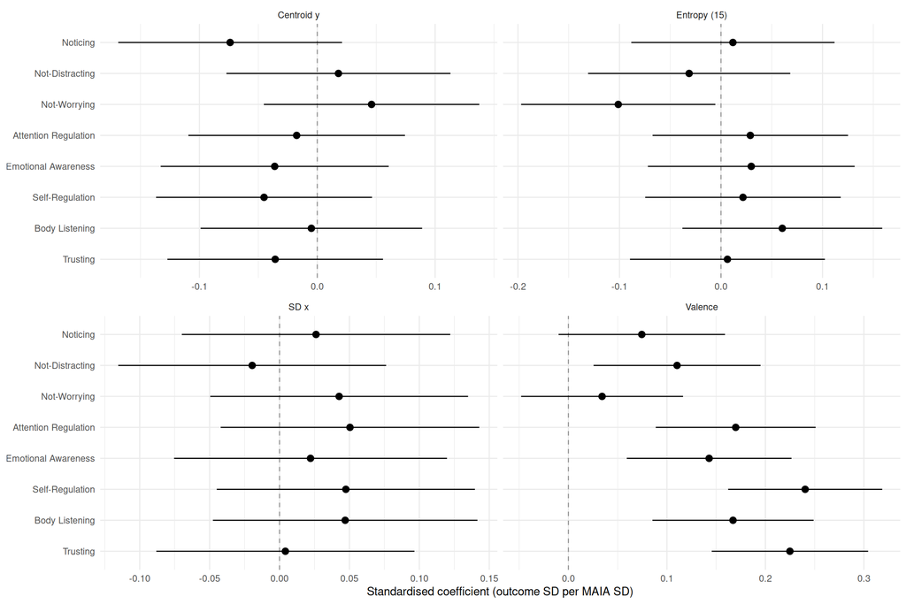

```r
f2 <- results |>
  filter(study == "Study 2") |>
  ggplot(aes(x = estimate, y = subscale, xmin = ci_lo, xmax = ci_hi)) +
  geom_vline(xintercept = 0, linetype = 2, colour = "grey60") +
  geom_pointrange() +
  facet_wrap(~ outcome, scales = "free_x") +
  labs(x = "Standardised coefficient (outcome SD per MAIA SD)", y = NULL) +
  theme_minimal()

apa_fig(f2, "maia_forest_study2", fig_dir, width = 12, height = 8)
f2
```

```r
cat("\n", apa_fig_caption("Standardised association of each MAIA-2 subscale with each outcome \u2014 Study 2"), "\n")
```

```
##
##  **Figure 2**
##
## *Standardised association of each MAIA-2 subscale with each outcome — Study 2*
```

# Interpretation

`b` is the MAIA subscale fixed effect from `lmerTest::lmer` (Satterthwaite degrees of freedom). The remaining terms (`timepoint`, `group`, their interaction) are in every model but are not reported here; see the Study 1 and Study 2 reports for those. These are exploratory models, not corrected for multiple comparisons.